# Canterra Employee Attrition

Probability of Attrition Model and Analysis

Esha Navaneethakrishnan and Mabel Barba

2024-04-26

# 1 Executive Summary

Approximately 15% of employees leave the company every year, leading Canterra to speculate on the causes of such high attrition rates. We at E&M Analytics Consulting Firm aim to help Canterra assess the probability of attrition within the organization and to share insight into important factors relating to their high employee attrition. Canterra management can act on these findings to identify and engage with employees likely to experience attrition.

# 2 Problem Statement and Approach

Our primary tasks in this analysis were twofold:  
* Determine the most influential variables that influence the probability of attrition, model the probability of attrition and draw insights by deploying machine learning models that include K-Nearest Neighbors and Support Vector Machines.  
* Evaluate which model is optimal in predicting employee attrition at Canterra.

The introductory analysis consisted of exploring 4410 observations of 18 variables, assessing the univariate distributions of variables and their relationships to the target variable. The data pre-processing phase consisted in the split of the dataset into training and testing sets, using a 70% to 30% ratio. Subsequently, we examined columns and variables for missing values in both datasets, `train_data` and `test_data`, imputing NA values with the mean values of the training data. Since categorical variables can not be used directly in distance functions, such as Euclidean (used in the first model; kNN() function), we converted `BusinessTravel` to numerical using the `dummy_cols()` function. This dummy coded variable introduced new features `BusinessTravel_Travel_Frequenly` and `BusinessTravel_Travel_Rarely`. Additionally, we applied the resampling method to treat the unbalanced data seen with `Attrition` (the minority class at 16.12%). Last, we applied scaling to standardize the predictor variables in both the training and testing datasets for all our models. Following our analysis of 12 features across 4,410 observations, we constructed k-Nearest Neighbor and Support Vector Machine models, testing and analyzing different features to find the best performing classifier. Our findings are presented from the perspective of the model. The conclusion reveals the SVM-Radial-e1071 (Model 4) is the optimal approach to predict the probability of attrition. Due to the reliable, robust performance of the model in predicting employee attrition, we have confidence in our resulting recommendations.

# 3 Methodology

## 3.1 Introductory Analysis

Exploration - Our team began with an inspection of Canterra’s provided employee dataset. We discovered no duplicate observations, but did identify 73 instances of missing values which later in the analysis were replaced by imputing the mean values of the respective variable in the training data.

```
## 'data.frame':    4410 obs. of  18 variables:
##  $ Age                    : int  51 31 32 38 32 46 28 29 31 25 ...
##  $ Attrition              : Factor w/ 2 levels "No","Yes": 1 2 1 1 1 1 2 1 1 1 ...
##  $ BusinessTravel         : Factor w/ 3 levels "Non-Travel","Travel_Frequently",..: 3 2 2 1 3 3 3 3 3 1 ...
##  $ DistanceFromHome       : int  6 10 17 2 10 8 11 18 1 7 ...
##  $ Education              : int  2 1 4 5 1 3 2 3 3 4 ...
##  $ EmployeeID             : int  1 2 3 4 5 6 7 8 9 10 ...
##  $ Gender                 : Factor w/ 2 levels "Female","Male": 1 1 2 2 2 1 2 2 2 1 ...
##  $ JobLevel               : int  1 1 4 3 1 4 2 2 3 4 ...
##  $ MaritalStatus          : Factor w/ 3 levels "Divorced","Married",..: 2 3 2 2 3 2 3 2 2 1 ...
##  $ Income                 : int  131160 41890 193280 83210 23420 40710 58130 31430 20440 134640 ...
##  $ NumCompaniesWorked     : int  1 0 1 3 4 3 2 2 0 1 ...
##  $ StandardHours          : int  8 8 8 8 8 8 8 8 8 8 ...
##  $ TotalWorkingYears      : int  1 6 5 13 9 28 5 10 10 6 ...
##  $ TrainingTimesLastYear  : int  6 3 2 5 2 5 2 2 2 2 ...
##  $ YearsAtCompany         : int  1 5 5 8 6 7 0 0 9 6 ...
##  $ YearsWithCurrManager   : int  0 4 3 5 4 7 0 0 8 5 ...
##  $ EnvironmentSatisfaction: int  3 3 2 4 4 3 1 1 2 2 ...
##  $ JobSatisfaction        : int  4 2 2 4 1 2 3 2 4 1 ...
```

## 3.2 Target Variable

The Target variable in our analysis is `Attrition`. Canterra had previously reported that approximately 15% of their employees leave the company every year. This assertion is in agreement with our evaluation of the `Attrition` distribution. According to the marginal distribution of `Attrition`, we see that approximately 16.12% of our observations are of employees which have experienced attrition. Due to the moderate degree of imbalance (proportion of minority class between 1%-20%) we performed the ‘Oversampling’ resampling method to treat the skewed class in our training data set. The Oversampling method creates artificial data points of the minority class to balance the class label.

## 3.3 Predictor Variables

### 3.3.1 Categorical Variables

Categorical variables include `BusinessTravel`, `Gender`, `MaritalStatus`. On the whole, none of these variables distributions are equally distributed. For modeling purposes, the Variables `MaritalStatus` and `Gender` were excluded to consider resources constrains and make the dataset more manageable.

### 3.3.2 Continuous Variables

Continuous variables we are including in our analysis are `DistanceFromHome`, `Income`, `NumComaniesWorked`, `TotalWorkingYears`,`TrainingTimesLastYear`, `YearsAtCompany`, `YearsWithCurrManager`, `EnvironmentalStatisfaction`, `JobSatisfaction`. New features introduced after Dummy Encoding are `BusinessTravel_Travel_Frequently` and `BusinessTravel_Travel_Rarely` For modeling purposes, the Variables `Education` and `JobLevel` were excluded to consider resources constrains and make the dataset more manageable. We omitted the variable `Age`, as well, because in previous analysis revealed age to be a strong predictor for attrition. For this analysis, we wanted to start with a fresh perspective and in Phase 2 of the project incorporate `Age` back to our predicting models. Last, we omitted `EmployeeID` and `StandardHours` because one is a unique identifier and the latter is a constant value not relevant to the analysis.

### 3.3.4 Data Preprocessing

**Pre-process the data and prepare it for running the following classification models (KNN and SVM). (15 points)**

Feature Engineering: Dummy Coding - Since categorical variables can not be used directly in distance functions, such as Euclidean (used in the first model; kNN() function), we converted `BusinessTravel` to numerical datatype using the `dummy_cols()` function. This dummy coded variable introduced new features `BusinessTravel__Travel_Frequenly` and `BusinessTravel_Travel_Rarely`.  
Data Partition | Resampling | Missing Values - We conducted a split of the dataset into training and testing sets, using a 70% to 30% ratio. Splitting the data before any imputation or scaling is best practice to prevent data leak. Subsequently, we examined variables for missing values in both datasets, `train_data` and `test_data`, imputing NA values with the mean values of the training data. Additionally, we applied the resampling method to treat the unbalanced data seen with `Attrition`, 16.12% for the minority class ‘Yes’ vs 83.87%.  
Feature Engineering: Scaling - Last, we applied the scaling function to the predictor variables in both the training and testing datasets to standardize the variables.This step is critical because the features have different scales prone biased results due to the distance computation sensitivity of the models’ algorithms. Scaling ensures the model algorithms provide accurate and reliable results.

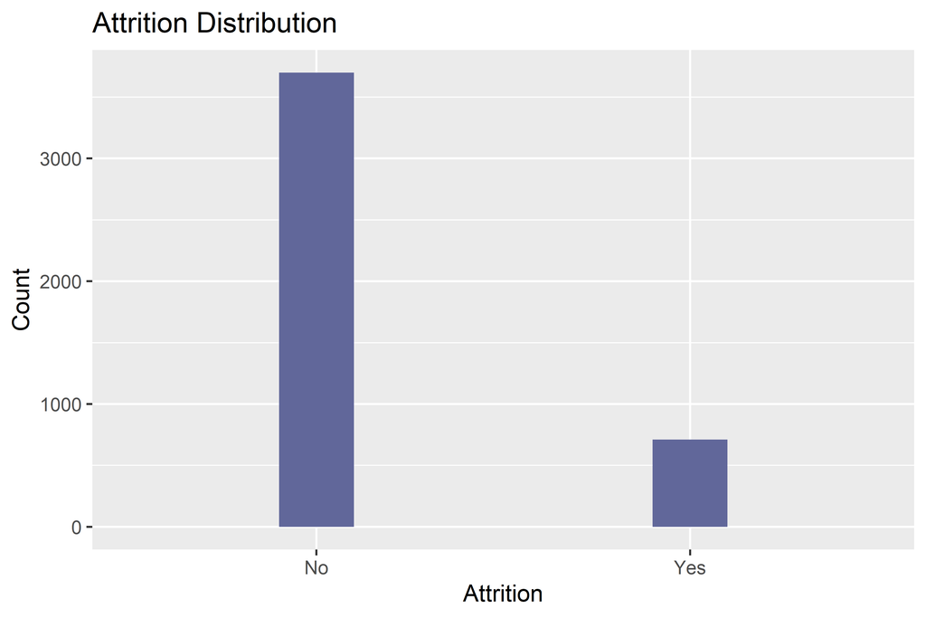

```
##
##        No       Yes
## 0.8387755 0.1612245
```

### 3.3.5 Model Building - k-Nearest Neighbor

**Run a K-Nearest Neighbor model to build a predictive model for employees’ attrition. Use values of k to find an optimal model. (25 points)** #### Model 1: kNN, knn() function | *About the Model 1* - The k-nearest neighbor algorithm is a non-parametric, supervised learning classifier, useful in both classification and regression, but in our analysis used for classification. The algorithm is highly unbiased and there is no need for prior assumption about the underlying data but the model does not help us understand how features are related to classes. The way this algorithm works is by calculating the distance, in Euclidean distance, between a query and all the examples in the data, selects the specified number of examples `k` closest to the query, then votes for the most frequent `label` (during classification). Prior running the algorithm, the data was standardized using the `scale()` function using the information from the train set to scale the test dataset.

*Output summary* - The model resulted with a 65% Accuracy to predict `Attrition` using the attributes given. Additionally, the metric Sensitivity, which measures how many were correctly classified as true positives, resulted in 73%. And, Specificity, which measures how many were correctly classified as true negative, resulted in 64%.

#### 3.3.5.1 Model 2: kNN, “caret” Package

*About the Model 2* - The “caret” package (Classification And Regression Training) is a set of functions that attempt to streamline the process for creating predictive models (Kuhn, 2019). It uses the general function `train()` that can handle many methods for predicting, in this use case we used the `knn` method. The preProcess parameter allows us to specify a list of pre-processing techniques to be applied to the training data. We set it to method = “center” which subtracts the mean of the predictor’s data from the predictor values while method = “scale” divides by the standard deviation (R Docs:Pre-Processing of Predictors).

*k-Fold Cross Validation* - The `trainControl()` function is used to specify the parameters for the resampling method during model training. In model 2, the method argument is set to “cv”, for cross-validation. This k-fold process divided the dataset into 10 subsets or folds, and the model was trained and tested 10 times. In each iteration, one of the folds was used as the test set, and the remaining 9 folds were used for training. The process was repeated 10 times, with each fold serving as the test set exactly once. The final performance metric is an average of the metrics obtained in each iteration.

*Choosing value of K* - We set the parameter tuneLength = 38 (`k` value) but the `train()` function from “caret” automatically chooses the best value of k to use in prediction. The Resampling results across tuning parameters selected `k=1` with an Accuracy of 98.91%. We do believe this smaller `k` value indicates an overfitting in Model 2 (and Model 1).

*Output summary* - Accuracy : 97.51% | Sensitivity : 89.30% (true positives) | Specificity : 99.10% (true negatives)

We conclude Model 2 is the best classifier for the k-nearest neighbor algorithm.

### 3.3.6 Model Building - SVM

**Run a Support Vector Machines model to build a predictive model for employees’ attrition. Try out different model settings to find an optimal model. (25 points)**

The “Support Vector Machines” (SVM) model is a supervised machine learning algorithm used for both classification and regression tasks. The primary objective of an SVM is to find the optimal hyperplane that best separates the data points of different classes in a high-dimensional space. Some of the key characteristics of the Support Vector Machine would be a hyperplane, support vectors, kernel trick, and a C-parameter; the kernel trick can handle non-linear decision boundaries, while the `C` parameter controls the trade-off when it comes to classifying training points and achieving a smooth decision boundary. The `tune()` function and the `e1071` package can be used for training and deploying SVM models; the “caret” package with the general function, `train()`, was also used to deploy the SVM model for the purposes of this report.

One of the advantages to SVM is the kernel trick and its simple interpretation. A disadvantages to SVM is its sensitivity to outliers, which the recommendation is to remove them and/or the scale the data.

#### 3.3.6.1 Model 3: SVM-Linear, “tune” function*

*About Model 3* - The SVM Model 3 uses the default kernel function, Linear, to add feature space. We used the `tune()` wrapper function in our code to perform the ten-fold cross-validation. Additionally, we created 6 searches for cost parameters (0.001,0.01,0.1,1,5,10) to find the best `c` parameter. The cost measures the error or missclassification rate:
$$1-Accuracy$$

*Output summary* - Accuracy: 63.34% | Sensitivity: 67.91% (true positives) | Specificity: 62.45% (true negative)

The algorithm found the best performance by lowest cross validation error of 0.3249459, for cost parameter of 0.01.

#### 3.3.6.2 Model 4: SVM-Radial, “e1071” package

*About Model 4* - The SVM Model 4 uses the kernel function, Radial or radial basis function (RBF), to add feature space. We used the `tune()` wrapper function in our code to perform the SVM algorithm and the ten-fold cross-validation. The Radial function offers the parameters for cost of misclassification and gamma. Gamma is a crucial hyperparameter that influences the flexibility of the model and its shape of the decision boundary. This parameter handles non-linear classification. A high gamma value translated to only the closest data points to the decision boundary will carry the weight leading to a smoother boundary. The gamma parameter works in conjunction with the regularization parameter cost. For example, high values of `C` and high values of `gamma` can result in overfitting, while low values of both can yield to underfitting.

We created 6 searches for cost parameters (0.001,0.01,0.1,1,5,10) to find the best `c` parameter. For `gamma` we added 4 searches (0.5,1,2,3). the `tune()` function performs by default 10-Fold Cross Validation.

*Output summary* - Accuracy: 97.35% | Sensitivity: 85.12% (true positives) | Specificity: 99.73% (true negative)

The algorithm found the best performance by lowest cross validation error of 0.0007874016, for cost parameter of 5 and gamma of 3. We concluded the model is not overfitted/underfitted based on the highest/lowest parameters that would indicate the model is underperforming (High 10|3, Low 0.01|0.5).

#### 3.3.6.3 Model 5: SVM-Radial, “caret” Package

*About Model 5* - For Model 5, we used the “svmRadial” kernel, we specified the 10-Fold Cross Validation and tested 10 different values of `c` by setting the parameter `tuneLength=10`. The “caret” package `train()` function allowed us to preprocess the data using “center” and “scale”. And, automatically chose the best value of `k` to use in the prediction.

*Output summary* - Accuracy: 93.2% | Sensitivity: 86.05% (true positive) | Specificity: 94.58% (true negative)

#### 3.3.6.4 Model Comparison

**Compare the best KNN and SVM models by their model evaluation metrics. Which is a better model, and why? (10 points)** | *Best kNN* - AUC for kNN.caret: 0.941999  
| *Best SVM* - AUC for SVM.Radial-e1071: 0.9802116

#Conclusion and Recommendation **Summarize your findings, discuss the pros and cons of your proposed models, and provide your recommendations to management based on insights generated from the above model. (15 points)**

After building and testing 5 models to predict attrition, we compared the 2 best classifiers which are Model 2: kNN, “caret” Package and Model 4: SVM-Radial, “e1071” package. Their AUC scores are 0.941999 and 0.9802116 respectively, confirming both perform well at distinguishing between the employees which will and will not leave Canterra. Additionally, their scores for Sensitivity (true positives) and Specificity (true negatives) are correctly classifying its true class. The classifier SVM-Radial-e1071 (Model 4) is the optimal approach to predict in general the probability of employee attrition. Model 2 performs better than Model 4 when classifying the true positives class.

Given our findings we recommend Canterra to decide if predicting the true positives is a priority or identifying the true negatives is. Model 2 performs slightly better at identifying employees experiencing attrition. While Model 4 performs slightly better at identifying non-attrition employees. Some of the most influential predictors such as YearsAtCompany, TotalWorkingYears, YearsWithCurrManager, JobSatisfaction, and EnvironmentSatisfaction. Canterra would find it most productive to focus on improving in these areas. It would prove fruitful to increase efforts around employees who have not been with the company for very long. It would be wise to implement programs and initiatives to help these employees feel a sense of belonging and encourage a high job satisfaction level.